# Case Study: How can a wellness company play it smart?

# Introduction

This is my attempt at tackling the Google Data Analytics Course’s Case Study (as part of Course #8).

BellaBeat is a high-tech manufacturer of health-focused products for women. It is a successful small company, but they have the potential to become a larger player in the global smart device market. Urška Sršen, cofounder and Chief Creative Officer of BellaBeat, believes that analyzing smart device fitness data can help unlock new growth opportunities for the company.

This presentation details my analysis of select datasets about smart device usage data in order to gain insights into how consumers use non-BellaBeat smart devices. These will then be applied to a specific BellaBeat product and be used to make marketing recommendations.

# Phase 1 - Ask

[figure not shown]

In this phase, I considered the business task and what questions I could “ask” of the data through my analysis in order to gain helpful information.

Data analysis is applied to answer real-world questions, typically to accomplish a business task, but the process itself has to be motivated by SMART questions (Specific, Measurable, Action-Oriented, Relevant and Time-Bound).

#### *Business Task*

Identify potential opportunities for growth and recommendations for the BellaBeat marketing strategy improvement based on trends in smart device usage.

#### *Questions*

With the aforementioned business task as a compass, the most pertinent questions to provide an answer to in the span of this analysis are the following 3: 1) What are some trends in smart device usage? 2) How do these trends apply to BellaBeat customers? 3) How could these trends help influence BellaBeat marketing strategy?

# Phase 2 - Prepare

[figure not shown]

Now that the business and analysis objectives have been clearly laid out, the next step in the process is to fetch, examine, organize and otherwise prepare the data for analysis.

For this project, I will use FitBit Fitness Tracker Data, which is the recommended dataset (https://www.kaggle.com/datasets/arashnic/fitbit). This data set contains personal fitness tracker from 30 eligible Fitbit users, which consented to the submission of personal tracker data, including minute-level output for physical activity, heart rate, and sleep monitoring. It includes information about daily activity, steps, and heart rate that can be used to explore users’ habits.

It is important to evaluate data sources before even proceeding to analysis, to verify whether it is reliable, unbiased, and sufficient to work with for the purposes of the analysis being undertaken.

1. Reliable (✔): While the data collected on each individual is comprehensive, there are only 30 records, which makes for a very limiting sample size, prone to errors.
2. Original (✔): In the Kaggle webpage for the dataset, under the “Provenance” section of the metadata, a source is listed (https://zenodo.org/record/53894#.X9oeh3Uzaao), which provides a citation:

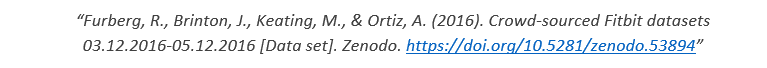

According to the description: “THESE DATASETS WERE GENERATED BY RESPONDENTS TO A DISTRIBUTED SURVEY VIA AMAZON MECHANICAL TURK BETWEEN 03.12.2016 – 05.12.2016.”. The origin of the dataset can be traced back to a trustworthy digital resource, which may provide further information if necessary.

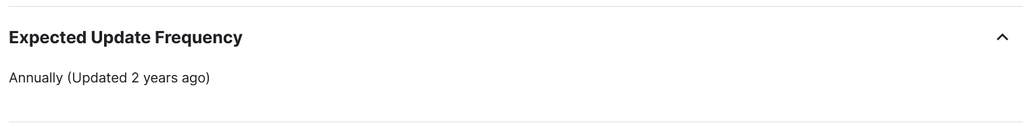

5. Cited (✔): As can be seen from its Kaggle webpage, the Fitbit data provided is highly discussed and cited, and many different people are working on them, giving rise to an active community of data analysts that constantly review and process the data, lending it credibility.

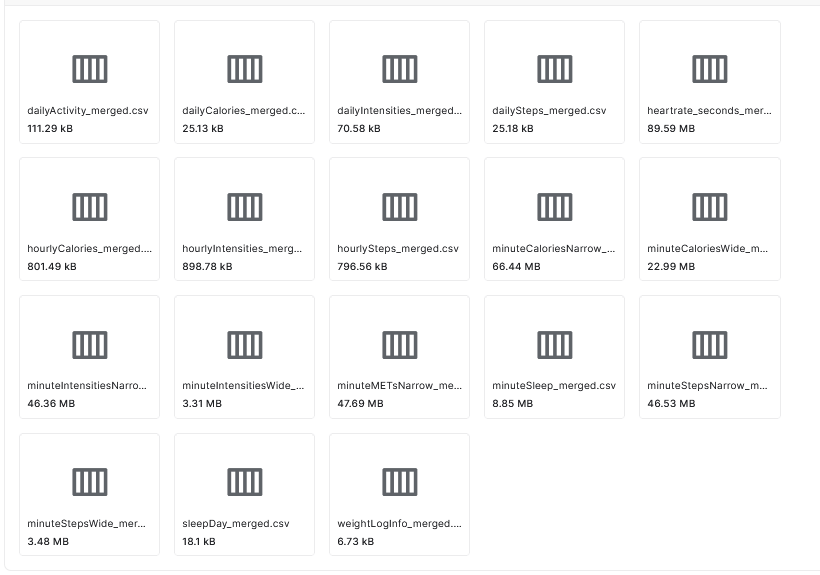

# Phase 3 - Process

[figure not shown]

After downloading and making a copy of the original data in my computer, I proceed to inspect the files in google sheets for spelling errors, empty values, or to make appropriate modifications in formatting.

Though the dataset was already quite clean, there were a few formatting changes I made before analyzing:

Change Log:

- I formatted every column featuring distances and rounded up the figures to the first 2 decimals, giving a consistent appearance to them. Most of the data had a trailing tail of ’9’s, long past the significant digits the measurements should have.
- I formatted every column featuring average intensity and rounded up the figures to the first 3 decimals, giving a consistent appearance to them. A lot of the data had a trailing tail of ’3’s and ’6’s, long past the significant digits the measurements should have.
- I made sure all datetime values had a common format: MM/DD/YY HH:MM:SS [AM|PM]
- In “hourlyIntensities_merged.csv”, there were actually 3 duplicate rows, which I removed.
- I formatted weight values (whether in kilograms or pounds) to 1 decimal digit.
- I formatted BMR values to 2 decimal digits.
- In “weightLogInfo_merged.csv”, the column “Fat” was removed. It only had 2 values, which made it useless for analysis.
- In every file, I took date columns and split them into distinct dates and times to facilitate analysis. Specifically, the original columns were kept as is and up to 2 new columns “date” and “time” were added. I say “up to” because not all files had datetimes with precise time information.
- When working with the activities data (hourlyIntensities_merged.csv), I encountered trouble with the formatting. The time data was being parsed as text for some reason, which messed up the ordering of the times and the look of the graph.

Not having a lot of experience with R, I struggled with it, but ultimately found no other fix for this than to reformat the times (‘time’ field) into simple numerical values (0-23). I ended up using this modified file instead (hourlyIntensities_merged_alt.csv).

# Phase 4 - Analyze

[figure not shown]

#### *Loading Packages*

```r
library(tidyverse) # Basic Utilities
library(lubridate) # Datetime Helper Module
```

```r
library(dplyr)     # Data Transformation
library(ggplot2)   # Plotting
library(tidyr)     # Data Cleaning
library(here)      # Setting Consistent CWD
```

#### *Importing Datasets*

For this project, I will use FitBit Fitness Tracker [Data](https://www.kaggle.com/arashnic/fitbit).

```r
activity <- read.csv(here("data/cleaned","dailyActivity_merged.csv"))
calories <- read.csv(here("data/cleaned","hourlyCalories_merged.csv"))
intensities <- read.csv(here("data/cleaned","hourlyIntensities_merged_alt.csv"))
sleep <- read.csv(here("data/cleaned","sleepDay_merged.csv"))
steps <- read.csv(here("data/cleaned","dailySteps_merged.csv"))
```

#### *Data Exploration*

Now that packages and files are ready and loaded, It is time to start exploring the data. Although there were 100’s of records in some files, a lot of them corresponded to the same ID. The dataset mentioned 30 participants, but that may not have referred to every aspect of data collection.

It is basic to count exactly how many participants we have in each individual dataset. We can accomplish this simply by counting the distinct ‘Id’ values in each file:

```r
n_distinct(activity$Id)
```

```
## [1] 33
```

```r
n_distinct(steps$Id)
```

```
## [1] 33
```

```r
n_distinct(calories$Id)
```

```
## [1] 33
```

```r
n_distinct(intensities$Id)
```

```
## [1] 33
```

```r
n_distinct(sleep$Id)
```

```
## [1] 24
```

The most basic type of information one can extract from a dataset is summary statistics (means, minima, maxima, and quartiles, AKA “measures of center”, which convey how the data is centered/clustered). Let’s have a look at each individual dataset:

```r
# activity
activity %>%
  select(TotalSteps,
         TotalDistance,
         SedentaryMinutes, Calories) %>%
  summary()
```

```
##    TotalSteps    TotalDistance    SedentaryMinutes    Calories
##  Min.   :    0   Min.   : 0.000   Min.   :   0.0   Min.   :   0
##  1st Qu.: 3790   1st Qu.: 2.620   1st Qu.: 729.8   1st Qu.:1828
##  Median : 7406   Median : 5.245   Median :1057.5   Median :2134
##  Mean   : 7638   Mean   : 5.490   Mean   : 991.2   Mean   :2304
##  3rd Qu.:10727   3rd Qu.: 7.713   3rd Qu.:1229.5   3rd Qu.:2793
##  Max.   :36019   Max.   :28.030   Max.   :1440.0   Max.   :4900
```

```r
# activity -> number of active minutes per category
activity %>%
  select(VeryActiveMinutes, FairlyActiveMinutes, LightlyActiveMinutes) %>%
  summary()
```

```
##  VeryActiveMinutes FairlyActiveMinutes LightlyActiveMinutes
##  Min.   :  0.00    Min.   :  0.00      Min.   :  0.0
##  1st Qu.:  0.00    1st Qu.:  0.00      1st Qu.:127.0
##  Median :  4.00    Median :  6.00      Median :199.0
##  Mean   : 21.16    Mean   : 13.56      Mean   :192.8
##  3rd Qu.: 32.00    3rd Qu.: 19.00      3rd Qu.:264.0
##  Max.   :210.00    Max.   :143.00      Max.   :518.0
```

```r
# steps
steps %>%
  select(StepTotal) %>%
  summary()
```

```
##    StepTotal
##  Min.   :    0
##  1st Qu.: 3790
##  Median : 7406
##  Mean   : 7638
##  3rd Qu.:10727
##  Max.   :36019
```

```r
# calories
calories %>%
  select(Calories) %>%
  summary()
```

```
##     Calories
##  Min.   : 42.00
##  1st Qu.: 63.00
##  Median : 83.00
##  Mean   : 97.39
##  3rd Qu.:108.00
##  Max.   :948.00
```

```r
# sleep
sleep %>%
  select(TotalSleepRecords, TotalMinutesAsleep, TotalTimeInBed) %>%
  summary()
```

```
##  TotalSleepRecords TotalMinutesAsleep TotalTimeInBed
##  Min.   :1.00      Min.   : 58.0      Min.   : 61.0
##  1st Qu.:1.00      1st Qu.:361.0      1st Qu.:403.8
##  Median :1.00      Median :432.5      Median :463.0
##  Mean   :1.12      Mean   :419.2      Mean   :458.5
##  3rd Qu.:1.00      3rd Qu.:490.0      3rd Qu.:526.0
##  Max.   :3.00      Max.   :796.0      Max.   :961.0
```

Already, there are some noteworthy patterns we can notice:

#### *Combining Datasets*

The data is in different files at the moment. In order to look for relations and patterns graphically, variables from different datasets have to be brought together into the same data frame. It is best if this happens temporarily, as to leave the data sources intact. This calls for an inner join operation.

```r
merged_data <- merge(sleep, activity, by=c('Id', 'date'))
head(merged_data)
```

|  | Id | date | SleepDay | TotalSleepRecords | TotalMinutesAsleep | TotalTimeInBed | ActivityDate | TotalSteps | TotalDistance | TrackerDistance | LoggedActivitiesDistance | VeryActiveDistance | ModeratelyActiveDistance | LightActiveDistance | SedentaryActiveDistance | VeryActiveMinutes | FairlyActiveMinutes | LightlyActiveMinutes | SedentaryMinutes | Calories |
| --- | --- | --- | --- | --- | --- | --- | --- | --- | --- | --- | --- | --- | --- | --- | --- | --- | --- | --- | --- | --- |
| 1 | 1503960366 | 4/12/2016 | 04/12/16 12:00:00 AM | 1 | 327 | 346 | 4/12/2016 | 13162 | 8.50 | 8.50 | 0 | 1.88 | 0.55 | 6.06 | 0 | 25 | 13 | 328 | 728 | 1985 |
| 2 | 1503960366 | 4/13/2016 | 04/13/16 12:00:00 AM | 2 | 384 | 407 | 4/13/2016 | 10735 | 6.97 | 6.97 | 0 | 1.57 | 0.69 | 4.71 | 0 | 21 | 19 | 217 | 776 | 1797 |
| 3 | 1503960366 | 4/15/2016 | 04/15/16 12:00:00 AM | 1 | 412 | 442 | 4/15/2016 | 9762 | 6.28 | 6.28 | 0 | 2.14 | 1.26 | 2.83 | 0 | 29 | 34 | 209 | 726 | 1745 |
| 4 | 1503960366 | 4/16/2016 | 04/16/16 12:00:00 AM | 2 | 340 | 367 | 4/16/2016 | 12669 | 8.16 | 8.16 | 0 | 2.71 | 0.41 | 5.04 | 0 | 36 | 10 | 221 | 773 | 1863 |
| 5 | 1503960366 | 4/17/2016 | 04/17/16 12:00:00 AM | 1 | 700 | 712 | 4/17/2016 | 9705 | 6.48 | 6.48 | 0 | 3.19 | 0.78 | 2.51 | 0 | 38 | 20 | 164 | 539 | 1728 |
| 6 | 1503960366 | 4/19/2016 | 04/19/16 12:00:00 AM | 1 | 304 | 320 | 4/19/2016 | 15506 | 9.88 | 9.88 | 0 | 3.53 | 1.32 | 5.03 | 0 | 50 | 31 | 264 | 775 | 2035 |

# Phase 5 - Share

[figure not shown]

#### *Data Visualization*

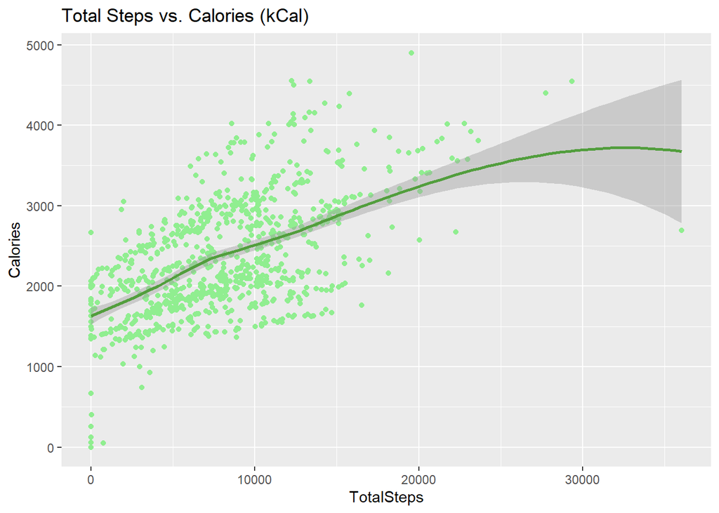

```r
ggplot(data=activity, aes(x=TotalSteps, y=Calories)) +
  geom_point(color='lightgreen') + geom_smooth(color='#529e3d') +
  labs(title="Total Steps vs. Calories (kCal)")
```

As can be seen from the graph, there is a clear positive correlation between the total number of steps taken each day and consumed calories (kCal), a fairly expected pattern, but it confirms the data has been collected without error, if nothing else, a “sanity check” that vouches for the overall credibility of the data. Let us now examine the data we have on the intensity of exercise over time (an hourly basis, to be specific).

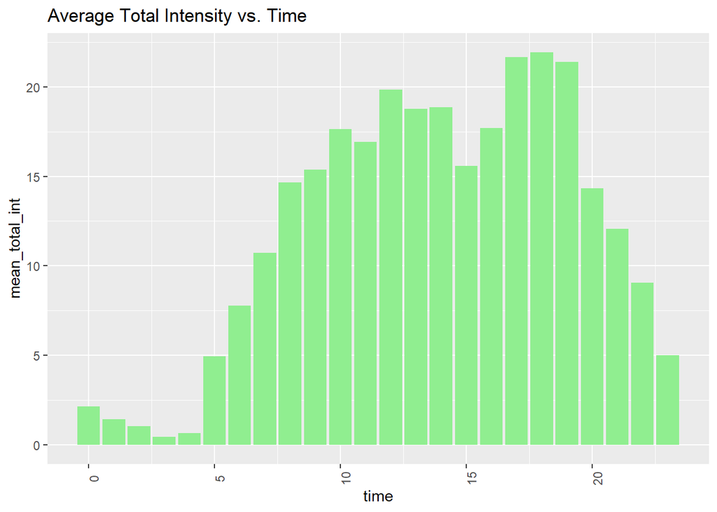

```r
int_new <- intensities %>%
  group_by(time) %>%
  summarise(mean_total_int = mean(TotalIntensity))

ggplot(data=int_new, aes(x=time, y=mean_total_int)) +
  geom_histogram(stat = "identity", fill='lightgreen') +
  theme(axis.text.x = element_text(angle = 90)) +
  labs(title="Average Total Intensity vs. Time")
```

Now we’ll look at possible patterns between the time spent asleep and time spent idle.

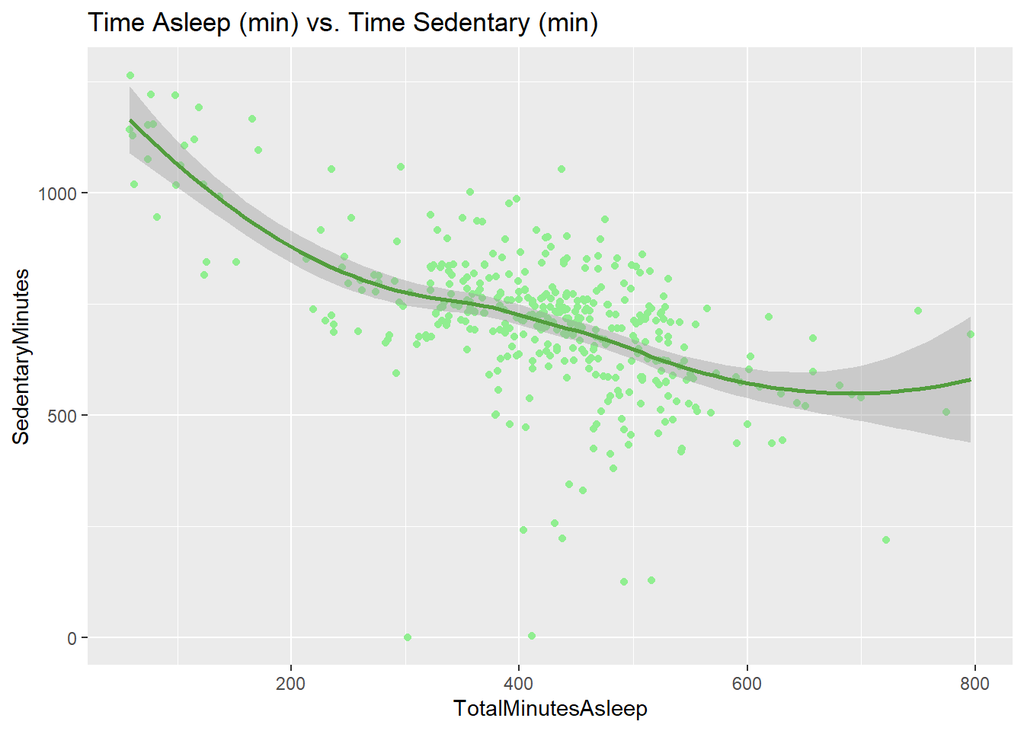

```r
ggplot(data=merged_data, aes(x=TotalMinutesAsleep, y=SedentaryMinutes)) +
geom_point(color='lightgreen') + geom_smooth(color='#529e3d') +
  labs(title="Time Asleep (min) vs. Time Sedentary (min)")
```

Here, one can clearly see a negative correlation between sedentary and sleep time. This can be interpreted simply as that users that sleep less tend to be more sedentary throughout the rest of the day because of low energy levels. But perhaps this can also mean that spending less time sedentary throughout the day makes people tend to go to bed earlier than usual, and get more sleep. With confirmatory data, this could prove to be a useful insight.

# Phase 6 - Act

[figure not shown]

Collecting data on activity, sleep, stress, and reproductive health has allowed BellaBeat to empower women with knowledge about their own health and habits. Having performed an analysis on the FitBit Fitness Tracker public dataset, some insights can now be gleaned that will aid BellaBeat in their marketing strategy. But that isn’t to say there is a one-size-fits-all approach for every customer. Indeed, the first benefit of this analysis is it allows us to distinguish what types of end-users have seen value in BellaBeat products:

Use-Case 1) There are women who work full-time and spend a lot of time idle (possibly just because of their work). According to the intensity and sedentary time data, these users already likely perform some mild physical activity throughout their day, but would noticeably benefit from increasing it.

The best way to motivate them would be to give them accurate tracking not only of how many calories they’ve expended due to the activity, but also attach brief informational notes on what losing those X or Y calories actually *means* for their health - making for a tangible sense of reward and motivation.

Use-Case 2) There are those who suffer in their health not because of their lack of exercise, but poor quality and/or quantity of sleep. This is an area their BellaBeat tracker could easily advise them in. Measuring their minutes asleep, they can gauge how long they sleep every day, whether their sleep is frequently interrupted at night (a new source of information) and prompt them to see the significance of improving their sleep habits.

Use-Case 3) As can be seen from the graph, the vast majority of participants walk less than 20,000 steps a day, but there are still those who go above the goal of 10,000. Being that they lack neither motivation nor time to exercise, these users may instead benefit from a goal-setting feature, where they program in advance the number of steps or calories they are aiming for every day. That would motivate them to exercise more, as well as use BellaBeat products to do so more effectively.

Use-Case 4) For most people, which are struggling to maintain a work-life balance, adding exercise to the mix can be exhausting. Rather than urge them with daily goals and give advise on strict sleep and diet regulation, it may be best to initially make them more mindful of how much they are sedentary every day. Just from the day I could find in the FitBit dataset, the minutes spent sedentary can provide that on a daily basis. Making people more mindful by setting notifications 1 or 2 times every day that they are spending hours and hours mostly staying still is likely to make them want to exercise, even if it’s just moving around their office space. From there, a habit of moving around can be encouraged to walking for 5 or 10 minutes during breaktimes in their day, which can turn into small and medium-sized exercise goals.

**Take-Home Message**

Just like with this case study, BellaBeat must show that they don’t just “give data” or “provide colorful charts”, but directly connect the value of the data to a person’s daily life and demonstrate how it can serve as a concrete path to improving oneself.

Thank you for Reading!

[figure not shown]